# dodgr isochrones, isodists, and isoverts

Mark Padgham

2020-05-05

The `dodgr`package includes three functions for calculating iso-contours from one or more points of origin: [`dodgr_isodists()`](https://atfutures.github.io/dodgr/reference/dodgr_isodists.html) for contours of equal distance; [`dodgr_isochrones()`](https://atfutures.github.io/dodgr/reference/dodgr_isochrones.html) for contours of equal time; and [`dodgr_isoverts()`](https://atfutures.github.io/dodgr/reference/dodgr_isoverts.html) to return full set of vertices within defined isodistance or isochrone contours.

Each of these functions is fully vectorised to accept both multiple origin points and multiple contours. Each returns a single `data.frame` object, with a column specifying either the distance limit (as `dlim` for [`dodgr_isodists()`](https://atfutures.github.io/dodgr/reference/dodgr_isodists.html) ,or `tlim` for [`dodgr_isochrones()`](https://atfutures.github.io/dodgr/reference/dodgr_isochrones.html)). The functions are also internally parallelised for efficient calculation.

## dodgr_isodists

The [`dodgr_isodists()`](https://atfutures.github.io/dodgr/reference/dodgr_isodists.html) function calculates contours of equal distance from one or more points of origin.

```r
graph <- weight_streetnet (hampi)
from <- sample (graph$from_id, size = 100)
dlim <- c (1, 2, 5, 10, 20) * 100
d <- dodgr_isodists (graph, from = from, dlim)
dim (d)
```

```
## [1] 1804    5
```

```r
knitr::kable (head (d))
```

| from | dlim | id | x | y |
| --- | --- | --- | --- | --- |
| 977473118 | 100 | 1143452406 | 76.46110 | 15.34093 |
| 977473118 | 100 | 1143452538 | 76.46162 | 15.34113 |
| 977473118 | 100 | 1143452406 | 76.46110 | 15.34093 |
| 977473118 | 200 | 2627422264 | 76.46112 | 15.34006 |
| 977473118 | 200 | 2627422262 | 76.46119 | 15.34023 |
| 977473118 | 200 | 1143452213 | 76.46239 | 15.34117 |

This function returns in this case a `data.frame` with the columns shown above and 1,804 points defining the isodistance contours from each origin (`from`) point, at the specified distances of 100, 200, 500, 1000, 2000 metres. There are naturally more points defining the contours at longer distances:

```r
table (d$dlim)
```

```
##
##  100  200  500 1000 2000
##  193  269  358  447  537
```

The points defining the contours are arranged in an anticlockwise order around each point of origin, and so can be directly visualised using base graphics functions. This is easier to see by using just a single point of origin:

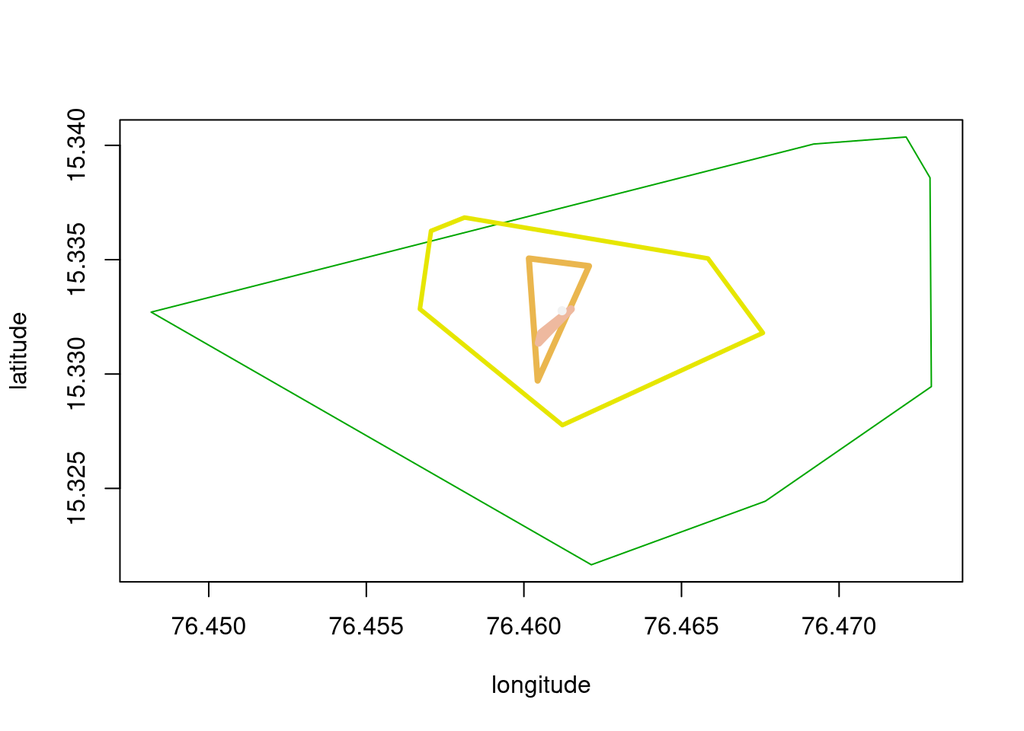

```r
from <- sample (graph$from_id, size = 1)
dlim <- c (1, 2, 5, 10, 20) * 100
d <- dodgr_isodists (graph, from = from, dlim)
cols <- terrain.colors (length (dlim))
index <- which (d$dlim == max (d$dlim)) # plot max contour first
plot (d$x [index], d$y [index], "l", col = cols [1],
      xlab = "longitude", ylab = "latitude")
for (i in seq (dlim) [-1]) {
    index <- which (d$dlim == rev (dlim) [i])
    lines (d$x [index], d$y [index], col = cols [i], lwd = i + 1)
}
```

The contours are convex hulls, so can not be guaranteed to entirely contain all internal contours, as that plot clearly reveals.